# PM566 Midterm Project

Leona Ma

10/24/2021

# Introduction:

Smoking can increase the risk of many ddiseaes, such as heart disease, stroke, and lung cancer. It is one of the most important risk factors of lung cancer. Tons of efforts have been done to prevent people from smoking. This data shows that how the proportion of four-level of smoking prevalence changed in adult over 1995-2011 in US. # Question: Was the proportion of American adults smoke decreasing during 1995-2011?

# Methods:

# Part 1 Data Cleaning and Wrangling

## Step1 reading and combining the data sets

```r
tobacco10 <- data.table::fread("tobacco2010.csv")
tobacco11 <- data.table::fread("tobacco2011.csv")
location <- data.table::fread("location.csv")
tobacco <- rbind(tobacco10, tobacco11)
tobacco11_L <- merge(tobacco11, location, by = "State")
```

Tobacco11_L missed two observations including nationwide data. But it’s fine, we don’t want nationwide data in map.

## Step2 creating two new variables “smokers and nonsmokers”

```r
tobacco[, smokers := `Smoke everyday`+`Smoke some days`]
tobacco[, nonsmokers := `Former smoker`+`Never smoked`]
```

## Step3 Spliting the data sets

```r
nation <- tobacco[State == "Nationwide (States and DC)" | State == "Nationwide (States, DC, and Territories)"]
area <- tobacco[!State == "Nationwide (States, DC, and Territories)" & !State == "Nationwide (States and DC)"]
```

# Part 2 Looking at the Data

```r
dim(tobacco)
head(tobacco)
tail(tobacco)
str(tobacco)
summary(tobacco$`Smoke everyday`)
summary(tobacco$`Smoke some days`)
summary(tobacco$`Former smoker`)
summary(tobacco$`Never smoked`)
```

[output not shown]

# Part 3 Preliminary Results

## Step 1 Taking a look at the top5 proportions of smokers and nonsmokers.

```r
top5_smoke <- tobacco[order(`smokers`,decreasing = TRUE)][1:5]
tab <- top5_smoke[, .(Year = Year, State = State, `proportions of smokers` = smokers)]
knitr::kable(tab)
```

| Year | State | proportions of smokers |
| --- | --- | --- |
| 2003 | Guam | 34.1 |
| 2002 | Kentucky | 32.6 |
| 2002 | Guam | 31.9 |
| 1996 | Kentucky | 31.7 |
| 1999 | Nevada | 31.5 |

```r
top5_nonsmoke <- tobacco[order(`nonsmokers`,decreasing = TRUE)][1:5]
tab <- top5_nonsmoke[, .(Year = Year, State = State, `proportions of nonsmokers` = nonsmokers)]
knitr::kable(tab)
```

| Year | State | proportions of nonsmokers |
| --- | --- | --- |
| 2010 | Virgin Islands | 94.2 |
| 2008 | Virgin Islands | 93.6 |
| 2009 | Virgin Islands | 93.6 |
| 2005 | Virgin Islands | 91.9 |
| 2007 | Virgin Islands | 91.4 |

From these two table, we can see that the 5 highest proportions of smokers are concentrated on 1996-2003 period, and the 5 highest proportions of nonsmokers are concentrated on 2005-2010. They show a basic trend that proportion of smokers were decreasing. However, further data exploration is still needed to make conclusion.

## Step 2 Looing at smokers and nonsmokers overall in nationwide and statewide respectively

### Smokers nationwide:

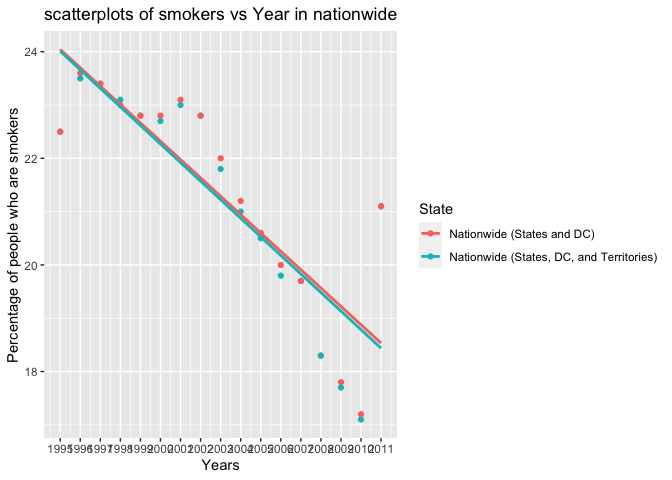

```r
ggplot(data = nation, mapping =aes(x = Year, y=smokers, color = State)) +
  geom_point() +
  geom_smooth(method=lm,se=FALSE, fullrange=TRUE) +
  scale_x_continuous(limits=c(1995, 2011), breaks = seq(1995, 2011, 1))+
  labs(title = "scatterplots of smokers vs Year in nationwide", x="Years", y="Percentage of people who are smokers")
```

From this plot we can see that adding data from territories didn’t change the trend much and it has some missing values, so just looking at the red line is fine. We can clearly see a decreasing trend in this plot. However, there is a small fluctuation between 2000-2003 and a relatively large increase from 2010 to 2011.

### Smokers in statewide

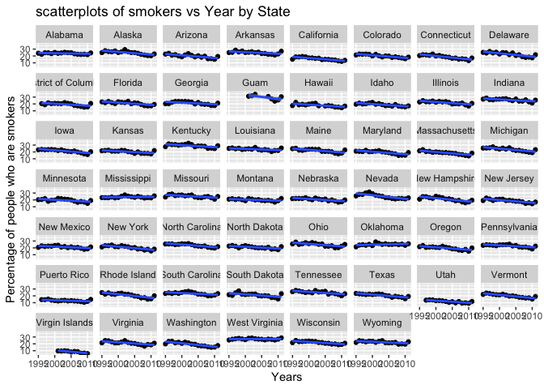

```r
ggplot(data=area, mapping=aes(x = Year, y = smokers)) +
  geom_point() +
  facet_wrap(~State) +
  geom_smooth(method='lm', formula = y~x)+
  labs(title = "scatterplots of smokers vs Year by State", x="Years", y="Percentage of people who are smokers")
```

From these plots,even thought they are pretty small, we can still see that most of them have the decreasing trend of smoker proportions, and the the last point is higher than the regression line. The small fluctuation can be found in some of the area, such as South Dakota and Nevada. Thus, the result from statewide is corresponding to that of nationwide. Since all the plots has the same y-scale, we can state that the overall proportion of smokers is the highest in Kentucky, and it is relatively low in Utah and Virgin Islands.

### Nonsmokers nationwide:

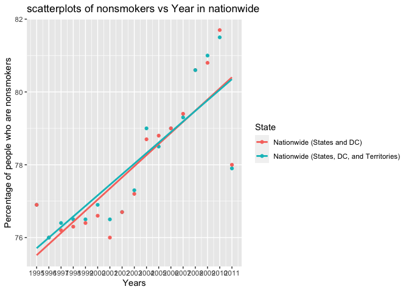

```r
ggplot(data = nation, mapping =aes(x = Year, y=nonsmokers, color = State)) +
  geom_point() +
  xlab("Years") + ylab("percentage") +
  geom_smooth(method=lm,se=FALSE, fullrange=TRUE) +
  scale_x_continuous(limits=c(1995, 2011), breaks = seq(1995, 2011, 1))+
  labs(title = "scatterplots of nonsmokers vs Year in nationwide", x="Years", y="Percentage of people who are nonsmokers")
```

### Nonmokers in statewide

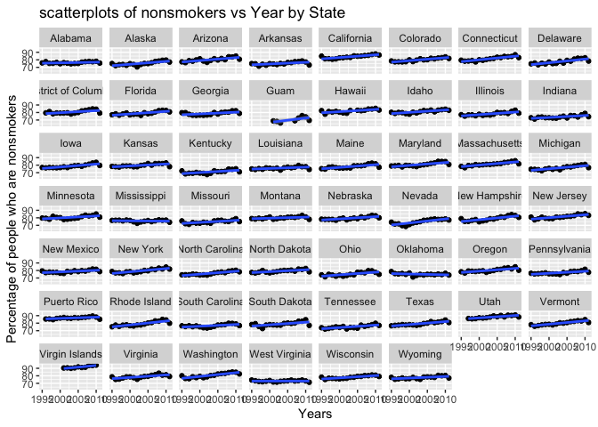

```r
ggplot(data=area, mapping=aes(x = Year, y = nonsmokers)) +
  geom_point() +
  facet_wrap(~State) +
  geom_smooth(method='lm', formula = y~x)+
  labs(title = "scatterplots of nonsmokers vs Year by State", x="Years", y="Percentage of people who are nonsmokers")
```

The result from proportions of nonsmokers are exactly opposite of that of the smokers. We can clearly see a increasing trend in nationwide plot.There is a small fluctuation between 2000-2003 and a relatively large decrease from 2010 to 2011. From the statewide plots, we can see that most of them have the increasing trend of nonsmoker proportions, and the the last point is lower than the regression line. The small fluctuation can be found in some of the area, such as South Dakota and Nevada. we also can state that the overall proportion of nonsmokers is the lowest in Kentucky, and it is relatively high in Utah and Virgin Islands.

## Step 3 Looing at 4-level of tobacoo use in nationwide and statewide respectively

### Smoke everyday in nationwide

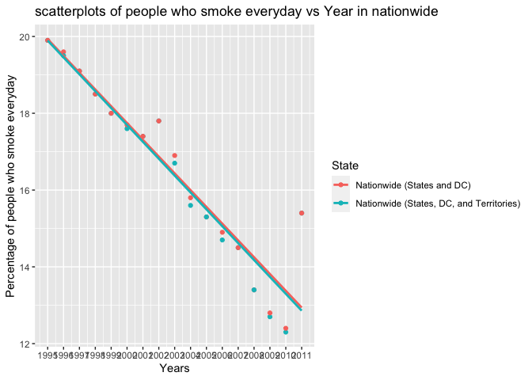

```r
ggplot(data = nation, mapping =aes(x = Year, y=`Smoke everyday`, color = State)) +
  geom_point() +
  geom_smooth(method=lm,se=FALSE, fullrange=TRUE) +
  scale_x_continuous(limits=c(1995, 2011), breaks = seq(1995, 2011, 1))+
  labs(title = "scatterplots of people who smoke everyday vs Year in nationwide", x="Years", y="Percentage of people who smoke everyday")
```

### Smoke everyday in statewide

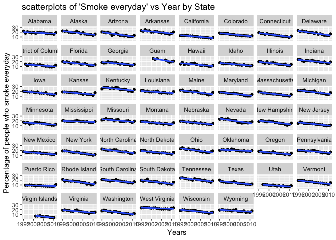

```r
ggplot(data=area, mapping=aes(x = Year, y = `Smoke everyday`)) +
  geom_point() +
  facet_wrap(~State) +
  geom_smooth(method='lm', formula = y~x)+
  labs(title = "scatterplots of 'Smoke everyday' vs Year by State", x="Years", y="Percentage of people who smoke everyday")
```

For proportions of people who smoke everyday, we can see that it is pretty similar with smokers overall, which has a clearly decreasing trend, little fluctuation and large increase in 2011. The difference is that the little fluctuation begins at 2002.

### Smoke some days in nationwide

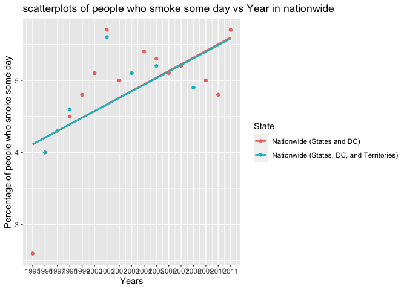

```r
ggplot(data = nation, mapping =aes(x = Year, y=`Smoke some days`, color = State)) +
  geom_point() +
  geom_smooth(method=lm,se=FALSE, fullrange=TRUE) +
  scale_x_continuous(limits=c(1995, 2011), breaks = seq(1995, 2011, 1))+
  labs(title = "scatterplots of people who smoke some day vs Year in nationwide", x="Years", y="Percentage of people who smoke some day")
```

### Smoke some days in statewide

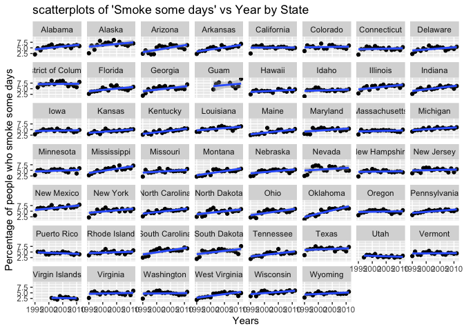

```r
ggplot(data=area, mapping=aes(x = Year, y = `Smoke some days`)) +
  geom_point() +
  facet_wrap(~State) +
  geom_smooth(method='lm', formula = y~x)+
  labs(title = "scatterplots of 'Smoke some days' vs Year by State", x="Years", y="Percentage of people who smoke some days")
```

### Former smoker in nationwide

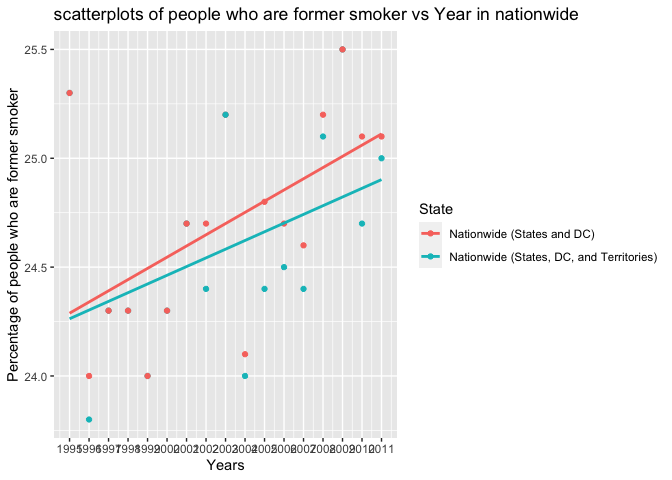

```r
ggplot(data = nation, mapping =aes(x = Year, y=`Former smoker`, color = State)) +
  geom_point() +
  geom_smooth(method=lm,se=FALSE, fullrange=TRUE) +
  scale_x_continuous(limits=c(1995, 2011), breaks = seq(1995, 2011, 1))+
  labs(title = "scatterplots of people who are former smoker vs Year in nationwide", x="Years", y="Percentage of people who are former smoker")
```

### Former smoker in statewide

[figure not shown]

```r
ggplot(data=area, mapping=aes(x = Year, y = `Former smoker`)) +
  geom_point() +
  facet_wrap(~State) +
  geom_smooth(method='lm', formula = y~x)+
  labs(title = "scatterplots of 'Smoke some days' vs Year by State", x="Years", y="Percentage of people who are former smoker")
```

From the plot of proportions of people who are former smokers, we can see the overall trend is increasing, but it fluctuates a lot. The trend is different across each state. My inference is that there had been people try to quit smoking, but it is hard to insist.